# SCAG Data Task

Zack Crowley

February 23, 2024

# Setup and Initial Instructions:

1. If this is the first time running this script, first update `R` and `Rstudio` (these are separate installations):
   - Follow the two steps at this [link](https://posit.co/download/rstudio-desktop/), be sure to select the versions of `R` and `Rstudio` that match your computer’s operating system.
2. Open/De-compress the `SCAG_data_task.zip`, open the folder “/SCAG_data_task”, here are the folders and files that it will contain and below is a directory tree to show the full structure:
   - `SCAG_data_task.Rmd` is the main file that contains all the R code to download, clean produce the
   - `SCAG_data_task.Rproj` is an R project file that is necessary to reproduce the file paths for all the code, used with R package `here`. Double clicking on this file will launch `Rstudio` as this R project.
   - `SCAG_data_task.html` is the walk through documentation that contains these instructions and all of the commentary inside this file `SCAG_data_task.Rmd` that is outside R code chunks.
   - The “/data” folder contains all of the raw ACS PUMS data both for the 5 year estimates of 2021 and 2022.
   - `data_cleaning_ACS.R` is a reference code for the data cleaning/new variable creation that takes place later in this file `SCAG_data_task.Rmd`.
   - The “/data_dictionaries” folder contains data dictionaries for reference both for the 5 year estimates of 2021 (`pums_vars_acs5_2021.csv`) and 2022 (`pums_vars_acs5_2022.csv`) and for new variables created for this analysis (`ACS_data_new_vars_tbl.csv`).
   - `style.css` is styling for the html output of `SCAG_data_task.html` (not necessary to know what this is).
   - “/images” folder contains screenshots for reference.

Directory Tree Diagram for folder “SCAG_data_task”:

```
## SCAG_data_task
## ├── SCAG_data_task.Rmd
## ├── SCAG_data_task.Rproj
## ├── SCAG_data_task.html
## ├── css
## │   └── style.css
## ├── data
## │   ├── 2017_2021_ACS_PUMS
## │   │   ├── csv_hca.zip
## │   │   └── csv_pca.zip
## │   └── 2018_2022_ACS_PUMS
## │       ├── csv_hca.zip
## │       └── csv_pca.zip
## ├── data_cleaning_ACS.R
## ├── data_dictionaries
## │   ├── ACS_data_new_vars_tbl.csv
## │   ├── pums_vars_acs5_2021.csv
## │   └── pums_vars_acs5_2022.csv
## └── images
##     └── run_code_chunk.png
```

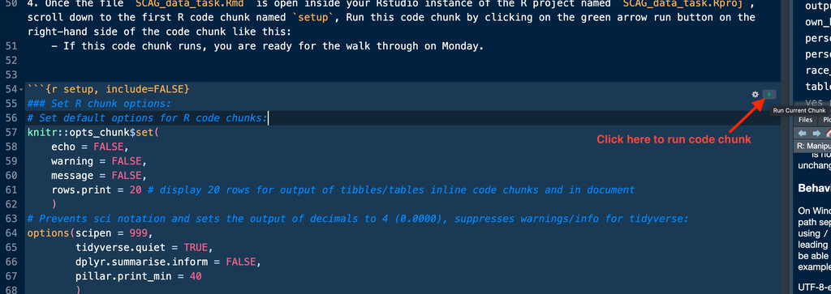

   - If this code chunk runs, you are ready for the walk through on Monday.

# Download, Read in, and Clean data from US Census ACS PUMS

### Download data from US Census American Community Survey (ACS) Public Use Microdata Sample (PUMS) File Transfer Protocol (FTP) site:

- The first step is retrieving the .csv files that make up both 5 year estimates from 2017-2021 and 2018-2022.
- The next code chunk will download each of the zip files for the housing and person level data, both for the 5 year estimates from 2017-2021 and 2018-2022.
- This code can be changed to retrieve the 2023 data once it is released in 2025.
- These files are located on the US Census American Community Survey (ACS) Public Use Microdata Sample (PUMS) [File Transfer Protocol (FTP) site](https://www2.census.gov/programs-surveys/acs/data/pums/2021/5-Year/)
- Links for 2017-2021 files:
  - Housing 2017-2021 PUMS .csv data link (clicking link will download the full large file): https://www2.census.gov/programs-surveys/acs/data/pums/2021/5-Year/csv_hca.zip
  - Person 2017-2021 PUMS .csv data link (clicking link will download the full large file): https://www2.census.gov/programs-surveys/acs/data/pums/2021/5-Year/csv_pca.zip
- Links for 2018-2022 files:
  - Housing 2018-2022 PUMS .csv data link (clicking link will download the full large file): https://www2.census.gov/programs-surveys/acs/data/pums/2022/5-Year/csv_hca.zip
  - Person 2018-2022 PUMS .csv data link (clicking link will download the full large file): https://www2.census.gov/programs-surveys/acs/data/pums/2022/5-Year/csv_pca.zip
- To get the URL’s for the desired .zip files, go to the FTP site, click on the desired year for the 5-year estimates.
  - The file name convention is `{file type}_{h=housing/p=person}{state abbreviation}.zip`, e.g. `csv_hca.zip` is a .csv file, for housing level data for the state of California (CA).
  - Right click on the .zip file and click “Copy Link Address”.
- This process takes about 5 minutes to download all files depending on your internet connection and can be skipped if you have the full .zip drive with the data files already downloaded.

### Data Dictionary Table (New Variables Created for Analysis):

- Below is a table of all the new variables created. It contains the variable name, a brief description, type of variable, and levels if it is a factor variable (levels will be used to sort these variables and control their order in the output).

| variable_name | description | type | levels |
| --- | --- | --- | --- |
| year | Year of ACS | numeric | NA |
| county | 6 counties that make up SCAG Region | factor | Imperial , Los Angeles , Orange , Riverside , San Bernardino, Ventura |
| race | 6 categories of race and ethnicity | factor | Asian/Pacific Islander, Black , Hispanic/Latino , Multiracial/Other , Native American , White |
| age_3_cat | 3 categories of age | factor | <18 years , 18 - 64 years, 65+ years |
| housing_income | Household Income US dollars, adjusted for inflation | numeric | NA |
| edu | 6 categories of educational attainment | factor | Less than HS Diploma, HS Diploma , Some College , AA Degree , BA degree , MA degree or higher |
| own_home | 2 categories of Homeownership | factor | Homeowner , Non-Homeowner |
| walk_bike_public_transport | 2 categories of Workers who Commute by Walk, Bike, or Public Transit or Other Transport | factor | Walk/Bike/Public, Other Transport |
| all_transport | 3 categories of means of transportation to work- Public, Private or Other | factor | Other , Public , Private |
| poverty | 2 categories: If Yes, the HH income is below 200 percent of the poverty line | factor: Yes, No | Yes, No |
| housing_burden | 2 categories: If Yes, Homeowner, owner costs as a percentage of hh income 30% or more (OCPIP), and 200 below percent poverty line (POVPIP) | factor: Yes, No | Yes, No |
| renter_burden | 2 categories: If Yes, Rent a home, Gross rent as a percentage of hh income 30% or more (GRPIP) and 200 below percent poverty line (POVPIP) | factor: Yes, No | Yes, No |
| no_kitchen_plumbing | 2 categories, If Yes, no kitchen and no plumbing facilities in home | factor: Yes, No | Yes, No |
| overcrowded | 2 categories of Overcrowding of households, If Yes, household has more than 1.5 persons per room | factor: Yes, No | Yes, No |
| hourly_wage | Hourly Wage US dollars, adjusted for inflation | numeric | NA |
| unemployed | Unemployment: if Yes, unemployed, No otherwise. | factor: Yes, No | Yes, No |
| single_hh | 3 categories of Single Parent Households by gender: female head of HH, male head of HH, or cohabitates or no kids | factor | female_hh , male_hh , cohabit_or_nokids |
| lep | 3 categories of English Proficiency: Limited English Proficiency, English Proficient, or Younger than 5 yos/speaks only English | factor | limited_english_proficiency, english_proficient , <5yos_or_only_eng |

### Load and Clean raw ACS PUMS FTP data

- This section will read in the raw data for the housing level data and person level data, selecting only the necessary variables for each with the given lists.
- Then, the files are merged- keeping all observations from the person level data and adding the columns from the housing data where SERIALNO matches, the merged data is then written out to a .csv file.
- The merged data is then filtered to the SCAG region, adding a county variable, and new variables created for later analysis as described in the previous section and in more detail in the file `data_cleaning_ACS.R`.
- Finally, the merged and cleaned data is written to a .csv file.
- This process is repeated for both the 2017-2021 and the 2018-2022 ACS PUMS in the next two code chunks, the only difference is that the 2022 data in the 2018-2022 ACS PUMS has PUMA’s drawn from the 2020 census (PUMA20), so this variable needed to be combined with the 2010 PUMA’s (PUMA10) to create an overall PUMA variable (PUMA).

#### 2017-2021 ACS PUMS data

- Preview of 2017-2021 clean ACS data for SCAG Region:

| SERIALNO | ST | PUMA | county | SPORDER | RELSHIPP | PWGTP | SEX | AGEP | HISP | RAC1P | ENG | NATIVITY | DIS | DDRS | DEAR | DEYE | DOUT | DPHY | DREM | SCHL | ESR | JWMNP | JWTRNS | WAGP | WKHP | ADJINC | POVPIP | HICOV | WGTP | … |
| --- | --- | --- | --- | --- | --- | --- | --- | --- | --- | --- | --- | --- | --- | --- | --- | --- | --- | --- | --- | --- | --- | --- | --- | --- | --- | --- | --- | --- | --- | --- |
| 2017000000067 | 6 | 3727 | Los Angeles | 1 | 20 | 20 | 1 | 47 | 1 | 1 | NA | 1 | 2 | 2 | 2 | 2 | 2 | 2 | 2 | 18 | 3 | NA | NA | 0 | 30 | 1117630 | 501 | 1 | 19 | … |
| 2017000000067 | 6 | 3727 | Los Angeles | 2 | 34 | 27 | 2 | 41 | 1 | 1 | NA | 1 | 2 | 2 | 2 | 2 | 2 | 2 | 2 | 21 | 1 | 25 | 1 | 70000 | 40 | 1117630 | 501 | 1 | 19 | … |
| 2017000000177 | 6 | 3732 | Los Angeles | 1 | 20 | 12 | 2 | 41 | 11 | 1 | 1 | 2 | 2 | 2 | 2 | 2 | 2 | 2 | 2 | 19 | 1 | 30 | 1 | 40000 | 40 | 1117630 | 275 | 1 | 12 | … |
| 2017000000177 | 6 | 3732 | Los Angeles | 2 | 21 | 14 | 1 | 59 | 11 | 1 | 2 | 2 | 2 | 2 | 2 | 2 | 2 | 2 | 2 | 16 | 6 | NA | NA | 0 | NA | 1117630 | 275 | 1 | 12 | … |
| 2017000000177 | 6 | 3732 | Los Angeles | 3 | 25 | 15 | 2 | 21 | 11 | 1 | 1 | 1 | 2 | 2 | 2 | 2 | 2 | 2 | 2 | 19 | 1 | 45 | 1 | 22000 | 38 | 1117630 | 275 | 1 | 12 | … |
| 2017000000177 | 6 | 3732 | Los Angeles | 4 | 25 | 15 | 1 | 20 | 11 | 1 | 1 | 1 | 2 | 2 | 2 | 2 | 2 | 2 | 2 | 14 | 3 | NA | NA | 720 | 8 | 1117630 | 275 | 1 | 12 | … |
| 2017000000191 | 6 | 3730 | Los Angeles | 1 | 20 | 14 | 2 | 38 | 1 | 1 | 1 | 1 | 2 | 2 | 2 | 2 | 2 | 2 | 2 | 24 | 1 | 35 | 1 | 100000 | 55 | 1117630 | 501 | 1 | 14 | … |
| 2017000000191 | 6 | 3730 | Los Angeles | 2 | 29 | 17 | 2 | 58 | 1 | 1 | 2 | 2 | 2 | 2 | 2 | 2 | 2 | 2 | 2 | 16 | 6 | NA | NA | 0 | NA | 1117630 | 501 | 1 | 14 | … |
| 2017000000204 | 6 | 3767 | Los Angeles | 1 | 20 | 10 | 1 | 60 | 2 | 1 | 1 | 2 | 2 | 2 | 2 | 2 | 2 | 2 | 2 | 21 | 1 | 10 | 1 | 102000 | 40 | 1117630 | 479 | 1 | 10 | … |
| 2017000000204 | 6 | 3767 | Los Angeles | 2 | 21 | 9 | 2 | 59 | 2 | 1 | 3 | 2 | 2 | 2 | 2 | 2 | 2 | 2 | 2 | 20 | 6 | NA | NA | 0 | NA | 1117630 | 479 | 1 | 10 | … |

#### 2018-2022 ACS PUMS data

- Preview of 2018-2022 clean ACS data for SCAG Region:

| SERIALNO | ST | PUMA | county | PUMA10 | PUMA20 | SPORDER | RELSHIPP | PWGTP | SEX | AGEP | HISP | RAC1P | ENG | NATIVITY | DIS | DDRS | DEAR | DEYE | DOUT | DPHY | DREM | SCHL | ESR | JWMNP | JWTRNS | WAGP | WKHP | ADJINC | POVPIP | … |
| --- | --- | --- | --- | --- | --- | --- | --- | --- | --- | --- | --- | --- | --- | --- | --- | --- | --- | --- | --- | --- | --- | --- | --- | --- | --- | --- | --- | --- | --- | --- |
| 2018GQ0000004 | 6 | 3701 | Los Angeles | 3701 | -9 | 1 | 37 | 6 | 1 | 30 | 2 | 8 | 1 | 1 | 2 | 2 | 2 | 2 | 2 | 2 | 2 | 14 | 6 | NA | NA | 500 | 40 | 1184371 | NA | … |
| 2018GQ0000016 | 6 | 3755 | Los Angeles | 3755 | -9 | 1 | 38 | 28 | 1 | 69 | 1 | 9 | NA | 1 | 1 | 2 | 2 | 2 | 2 | 1 | 2 | 17 | 6 | NA | NA | 0 | NA | 1184371 | 110 | … |
| 2018GQ0000027 | 6 | 6511 | Riverside | 6511 | -9 | 1 | 37 | 8 | 2 | 31 | 1 | 1 | NA | 1 | 2 | 2 | 2 | 2 | 2 | 2 | 2 | 18 | 6 | NA | NA | 0 | NA | 1184371 | NA | … |
| 2018GQ0000065 | 6 | 5909 | Orange | 5909 | -9 | 1 | 38 | 32 | 2 | 55 | 1 | 6 | 1 | 1 | 1 | 1 | 2 | 2 | 1 | 1 | 1 | 16 | 6 | NA | NA | 0 | NA | 1184371 | 56 | … |
| 2018GQ0000069 | 6 | 5914 | Orange | 5914 | -9 | 1 | 37 | 1 | 1 | 82 | 1 | 6 | 4 | 2 | 1 | 1 | 2 | 2 | 1 | 1 | 1 | 14 | 6 | NA | NA | 0 | NA | 1184371 | NA | … |
| 2018GQ0000080 | 6 | 6513 | Riverside | 6513 | -9 | 1 | 37 | 11 | 1 | 45 | 1 | 9 | NA | 1 | 2 | 2 | 2 | 2 | 2 | 2 | 2 | 19 | 6 | NA | NA | 0 | NA | 1184371 | NA | … |
| 2018GQ0000100 | 6 | 3711 | Los Angeles | 3711 | -9 | 1 | 38 | 22 | 2 | 18 | 7 | 1 | NA | 1 | 1 | 2 | 2 | 2 | 2 | 1 | 1 | 19 | 1 | NA | 11 | 300 | 18 | 1184371 | NA | … |
| 2018GQ0000119 | 6 | 3729 | Los Angeles | 3729 | -9 | 1 | 37 | 3 | 2 | 90 | 2 | 8 | 4 | 2 | 1 | 1 | 2 | 2 | 1 | 1 | 1 | 10 | 6 | NA | NA | 0 | NA | 1184371 | NA | … |
| 2018GQ0000129 | 6 | 3720 | Los Angeles | 3720 | -9 | 1 | 38 | 2 | 2 | 94 | 1 | 1 | NA | 1 | 1 | 1 | 2 | 2 | 1 | 1 | 2 | 14 | 6 | NA | NA | 0 | NA | 1184371 | 0 | … |
| 2018GQ0000147 | 6 | 2500 | Imperial | 2500 | -9 | 1 | 37 | 12 | 1 | 25 | 2 | 8 | NA | 1 | 2 | 2 | 2 | 2 | 2 | 2 | 2 | 18 | 6 | NA | NA | 0 | NA | 1184371 | NA | … |

# Read in clean SCAG Data

### **2018-2022 ACS PUMS Data for SCAG Region**

| SERIALNO | ST | PUMA | county | PUMA10 | PUMA20 | SPORDER | RELSHIPP | PWGTP | SEX | AGEP | HISP | RAC1P | ENG | NATIVITY | DIS | DDRS | DEAR | DEYE | DOUT | DPHY | DREM | SCHL | ESR | JWMNP | JWTRNS | WAGP | WKHP | ADJINC | POVPIP | … |
| --- | --- | --- | --- | --- | --- | --- | --- | --- | --- | --- | --- | --- | --- | --- | --- | --- | --- | --- | --- | --- | --- | --- | --- | --- | --- | --- | --- | --- | --- | --- |
| 2018GQ0000004 | 6 | 3701 | Los Angeles | 3701 | -9 | 1 | 37 | 6 | 1 | 30 | 2 | 8 | 1 | 1 | 2 | 2 | 2 | 2 | 2 | 2 | 2 | 14 | 6 | NA | NA | 500 | 40 | 1184371 | NA | … |
| 2018GQ0000016 | 6 | 3755 | Los Angeles | 3755 | -9 | 1 | 38 | 28 | 1 | 69 | 1 | 9 | NA | 1 | 1 | 2 | 2 | 2 | 2 | 1 | 2 | 17 | 6 | NA | NA | 0 | NA | 1184371 | 110 | … |
| 2018GQ0000027 | 6 | 6511 | Riverside | 6511 | -9 | 1 | 37 | 8 | 2 | 31 | 1 | 1 | NA | 1 | 2 | 2 | 2 | 2 | 2 | 2 | 2 | 18 | 6 | NA | NA | 0 | NA | 1184371 | NA | … |
| 2018GQ0000065 | 6 | 5909 | Orange | 5909 | -9 | 1 | 38 | 32 | 2 | 55 | 1 | 6 | 1 | 1 | 1 | 1 | 2 | 2 | 1 | 1 | 1 | 16 | 6 | NA | NA | 0 | NA | 1184371 | 56 | … |
| 2018GQ0000069 | 6 | 5914 | Orange | 5914 | -9 | 1 | 37 | 1 | 1 | 82 | 1 | 6 | 4 | 2 | 1 | 1 | 2 | 2 | 1 | 1 | 1 | 14 | 6 | NA | NA | 0 | NA | 1184371 | NA | … |
| 2018GQ0000080 | 6 | 6513 | Riverside | 6513 | -9 | 1 | 37 | 11 | 1 | 45 | 1 | 9 | NA | 1 | 2 | 2 | 2 | 2 | 2 | 2 | 2 | 19 | 6 | NA | NA | 0 | NA | 1184371 | NA | … |
| 2018GQ0000100 | 6 | 3711 | Los Angeles | 3711 | -9 | 1 | 38 | 22 | 2 | 18 | 7 | 1 | NA | 1 | 1 | 2 | 2 | 2 | 2 | 1 | 1 | 19 | 1 | NA | 11 | 300 | 18 | 1184371 | NA | … |
| 2018GQ0000119 | 6 | 3729 | Los Angeles | 3729 | -9 | 1 | 37 | 3 | 2 | 90 | 2 | 8 | 4 | 2 | 1 | 1 | 2 | 2 | 1 | 1 | 1 | 10 | 6 | NA | NA | 0 | NA | 1184371 | NA | … |
| 2018GQ0000129 | 6 | 3720 | Los Angeles | 3720 | -9 | 1 | 38 | 2 | 2 | 94 | 1 | 1 | NA | 1 | 1 | 1 | 2 | 2 | 1 | 1 | 2 | 14 | 6 | NA | NA | 0 | NA | 1184371 | 0 | … |
| 2018GQ0000147 | 6 | 2500 | Imperial | 2500 | -9 | 1 | 37 | 12 | 1 | 25 | 2 | 8 | NA | 1 | 2 | 2 | 2 | 2 | 2 | 2 | 2 | 18 | 6 | NA | NA | 0 | NA | 1184371 | NA | … |

# Analysis and Replication of Tables and Figures for SCAG

- Each of the following code chunks will create a table to match the figures from the Equity Analysis report or RECBR and write it out to a .csv file to the folder `output/tables`.
- Below is a brief description of each table and the data it includes.

## Tables and Figures from Equity Analysis Technical Report- (EA report)

### Figure 5. Workers who Commute by Walk, Bike, or Public Transit by Race and Ethnicity

- Percentage of Workers who Commute by Walk, Bike, or Public Transit.
- Uses person level weights, excludes person who work from home.

| county | race | walk_bike_public_percentage |
| --- | --- | --- |
| Imperial | Asian/Pacific Islander | 2.61 |
| Imperial | Black | 9.89 |
| Imperial | Hispanic/Latino | 3.54 |
| Imperial | Multiracial/Other | 5.22 |
| Imperial | Native American | 8.04 |
| Imperial | White | 5.13 |
| Imperial | All Races | 3.90 |
| Los Angeles | Asian/Pacific Islander | 7.15 |
| Los Angeles | Black | 10.52 |
| Los Angeles | Hispanic/Latino | 9.58 |

[output cut: 39 more lines]

### Figure 6. Householders without a Vehicle by Race and Ethnicity

- Percentage of Households without a Vehicle.
- Uses household level weights, includes only housing level data.

| county | race | no_vehicle_percentage |
| --- | --- | --- |
| Imperial | Asian/Pacific Islander | 4.14 |
| Imperial | Black | 14.65 |
| Imperial | Hispanic/Latino | 6.25 |
| Imperial | Multiracial/Other | 2.73 |
| Imperial | Native American | 13.56 |
| Imperial | White | 4.46 |
| Imperial | All Races | 6.19 |
| Los Angeles | Asian/Pacific Islander | 8.53 |
| Los Angeles | Black | 16.13 |
| Los Angeles | Hispanic/Latino | 8.31 |

[output cut: 39 more lines]

### Figure 7. Workers’ Commute Times (Minutes) by Mode and Race and Ethnicity

- Workers’ Commute Times in Minutes by Mode of transportation, three categories:
  - Workers who Commute by bus, rail, taxi, or ferry: coded “Public”
  - Workers who Commute by Car or Motorcycle: coded level “Private”
  - Workers who Commute by Walk, Bike, or Other: coded level “Other”
- Uses person level weights, excludes person who work from home.

| county | race | transportation_type | mean_transit_times_in_minutes |
| --- | --- | --- | --- |
| Imperial | Asian/Pacific Islander | Any Transportation | 24.71 |
| Imperial | Asian/Pacific Islander | Private | 25.12 |
| Imperial | Asian/Pacific Islander | Public | 0.00 |
| Imperial | Asian/Pacific Islander | Other | 15.95 |
| Imperial | Black | Any Transportation | 20.25 |
| Imperial | Black | Private | 19.51 |
| Imperial | Black | Public | 0.00 |
| Imperial | Black | Other | 25.88 |
| Imperial | Hispanic/Latino | Any Transportation | 23.25 |
| Imperial | Hispanic/Latino | Private | 23.67 |

[output cut: 186 more lines]

### Figure 19. Renters and Homeowners Experiencing Housing Cost Burden by Race and Ethnicity

- Percentage of Renters and Homeowners Experiencing Housing Cost Burden, divided by household_type: Renters or Homeowners.
- Uses household level weights, includes only housing level data.

| county | race | household_type | burden_percentage |
| --- | --- | --- | --- |
| Imperial | Asian/Pacific Islander | Renters | 11.96 |
| Imperial | Black | Renters | 53.76 |
| Imperial | Hispanic/Latino | Renters | 48.81 |
| Imperial | Multiracial/Other | Renters | 15.52 |
| Imperial | Native American | Renters | 17.42 |
| Imperial | White | Renters | 25.90 |
| Imperial | All Races | Renters | 46.17 |
| Los Angeles | Asian/Pacific Islander | Renters | 28.33 |
| Los Angeles | Black | Renters | 37.20 |
| Los Angeles | Hispanic/Latino | Renters | 40.25 |

[output cut: 88 more lines]

### Figure 20. People Living in Households Without Kitchen and Plumbing Facilities by Race and Ethnicity

- Percentage of People Living in Households Without Kitchen and Plumbing Facilities.
- Uses household level weights, includes only housing level data.

| county | race | no_kitchen_plumbing_percentage |
| --- | --- | --- |
| Imperial | Asian/Pacific Islander | 0.00 |
| Imperial | Black | 0.00 |
| Imperial | Hispanic/Latino | 0.10 |
| Imperial | Multiracial/Other | 0.00 |
| Imperial | Native American | 1.86 |
| Imperial | White | 0.13 |
| Imperial | All Races | 0.12 |
| Los Angeles | Asian/Pacific Islander | 0.21 |
| Los Angeles | Black | 0.47 |
| Los Angeles | Hispanic/Latino | 0.28 |

[output cut: 39 more lines]

### Figure 21. Households with Severe Overcrowding by Race and Ethnicity

- Percentage of Households with Severe Overcrowding- defined as have more than 1.5 persons per room.
- Uses household level weights, includes only housing level data.

| county | race | overcrowded_percentage |
| --- | --- | --- |
| Imperial | Asian/Pacific Islander | 2.21 |
| Imperial | Black | 11.43 |
| Imperial | Hispanic/Latino | 4.67 |
| Imperial | Multiracial/Other | 0.00 |
| Imperial | Native American | 3.19 |
| Imperial | White | 0.74 |
| Imperial | All Races | 4.16 |
| Los Angeles | Asian/Pacific Islander | 5.20 |
| Los Angeles | Black | 2.88 |
| Los Angeles | Hispanic/Latino | 11.16 |

[output cut: 39 more lines]

### Figure 22. Homeownership by Race and Ethnicity

- Percentage of Homeownership.
- Uses household level weights, includes only housing level data.

| county | race | homeownership_percentage |
| --- | --- | --- |
| Imperial | Asian/Pacific Islander | 55.03 |
| Imperial | Black | 33.53 |
| Imperial | Hispanic/Latino | 54.14 |
| Imperial | Multiracial/Other | 84.15 |
| Imperial | Native American | 64.89 |
| Imperial | White | 75.94 |
| Imperial | All Races | 57.22 |
| Los Angeles | Asian/Pacific Islander | 54.51 |
| Los Angeles | Black | 32.80 |
| Los Angeles | Hispanic/Latino | 39.05 |

[output cut: 39 more lines]

### Figure 28. People without Health Insurance by Race and Ethnicity

- Percentage of People without Health Insurance.
- Uses person level weights.

| county | race | no_health_insurance_percentage |
| --- | --- | --- |
| Imperial | Asian/Pacific Islander | 7.89 |
| Imperial | Black | 11.38 |
| Imperial | Hispanic/Latino | 7.21 |
| Imperial | Multiracial/Other | 4.70 |
| Imperial | Native American | 15.55 |
| Imperial | White | 5.56 |
| Imperial | All Races | 7.19 |
| Los Angeles | Asian/Pacific Islander | 5.31 |
| Los Angeles | Black | 6.24 |
| Los Angeles | Hispanic/Latino | 13.39 |

[output cut: 39 more lines]

### Figure 39. Median Hourly Wage by Race and Ethnicity

- Median Hourly Wage: US dollars, adjusted for inflation and calculated for those respondents that worked more than 0 hours/week.
- Uses person level weights, includes only civilian workers, ages 25-64 years.

| county | race | med_hr_wage |
| --- | --- | --- |
| Imperial | Asian/Pacific Islander | 24.53 |
| Imperial | Black | 11.41 |
| Imperial | Hispanic/Latino | 17.26 |
| Imperial | Multiracial/Other | 16.91 |
| Imperial | Native American | 20.34 |
| Imperial | White | 24.11 |
| Imperial | All Races | 17.73 |
| Los Angeles | Asian/Pacific Islander | 27.40 |
| Los Angeles | Black | 23.54 |
| Los Angeles | Hispanic/Latino | 17.84 |

[output cut: 39 more lines]

### Figure 40. Unemployment by Race and Ethnicity

- Unemployment, Uses person level weights, excludes those respondents not in the labor force.

| county | race | unemployed_percentage |
| --- | --- | --- |
| Imperial | Asian/Pacific Islander | 6.02 |
| Imperial | Black | 8.59 |
| Imperial | Hispanic/Latino | 15.19 |
| Imperial | Multiracial/Other | 11.95 |
| Imperial | Native American | 8.10 |
| Imperial | White | 6.13 |
| Imperial | All Races | 13.93 |
| Los Angeles | Asian/Pacific Islander | 5.36 |
| Los Angeles | Black | 10.22 |
| Los Angeles | Hispanic/Latino | 6.82 |

[output cut: 39 more lines]

### Figure 41. Working Poor by Race and Ethnicity

- Percentage of Working Poor: if respondent is working and is less than 200 percent below the federal poverty line.
- Uses person level weights, includes only civilian workers, ages 25-64 years.

| county | race | working_poor_percentage |
| --- | --- | --- |
| Imperial | Asian/Pacific Islander | 24.01 |
| Imperial | Black | 28.41 |
| Imperial | Hispanic/Latino | 31.28 |
| Imperial | Multiracial/Other | 16.70 |
| Imperial | Native American | 27.82 |
| Imperial | White | 14.21 |
| Imperial | All Races | 29.12 |
| Los Angeles | Asian/Pacific Islander | 13.31 |
| Los Angeles | Black | 17.95 |
| Los Angeles | Hispanic/Latino | 27.11 |

[output cut: 39 more lines]

## Tables and Figures from Racial Equity Baseline Conditions Report (REBCR)

### Total Population by County and SCAG

- Total population calculated using person level weights.

| county | total_population |
| --- | --- |
| Imperial | 179639 |
| Los Angeles | 9934550 |
| Orange | 3175196 |
| Riverside | 2430326 |
| San Bernardino | 2180385 |
| Ventura | 841952 |
| SCAG | 18742048 |

### Race/Ethnicity Distribution (%) by County and SCAG Region

- Percentages of Race/Ethnicity calculated using person level weights.

| county | race | race_percentage |
| --- | --- | --- |
| Imperial | Asian/Pacific Islander | 1.25 |
| Imperial | Black | 2.30 |
| Imperial | Hispanic/Latino | 85.35 |
| Imperial | Multiracial/Other | 0.81 |
| Imperial | Native American | 0.66 |
| Imperial | White | 9.63 |
| Los Angeles | Asian/Pacific Islander | 14.84 |
| Los Angeles | Black | 7.61 |
| Los Angeles | Hispanic/Latino | 48.69 |
| Los Angeles | Multiracial/Other | 3.46 |

[output cut: 32 more lines]

### Age Distribution (%) by County and SCAG Region

- Percentages of Age categories calculated using person level weights, three categories:
  - <18 years
  - 18 - 64 years
  - 65+ years

| county | age_categories | percentage |
| --- | --- | --- |
| Imperial | <18 years | 28.34 |
| Los Angeles | <18 years | 21.05 |
| Orange | <18 years | 21.42 |
| Riverside | <18 years | 24.58 |
| San Bernardino | <18 years | 25.90 |
| Ventura | <18 years | 22.24 |
| SCAG | <18 years | 22.26 |
| Imperial | 18 - 64 years | 58.48 |
| Los Angeles | 18 - 64 years | 64.69 |
| Orange | 18 - 64 years | 63.19 |

[output cut: 11 more lines]

### Single Parent Households (%) by Gender of Head of Household and then by County and SCAG Region

- Percentages of Single Parent Households (%) by Gender using household level weights, two categories of gender_head_of_household:
  - female_hh = female head of household
  - male_hh = male head of household

| county | gender_head_of_household | single_parent_hh_percentage |
| --- | --- | --- |
| Imperial | female_hh | 11.21 |
| Los Angeles | female_hh | 6.02 |
| Orange | female_hh | 4.61 |
| Riverside | female_hh | 5.82 |
| San Bernardino | female_hh | 7.25 |
| Ventura | female_hh | 4.66 |
| SCAG | female_hh | 5.88 |
| Imperial | male_hh | 1.91 |
| Los Angeles | male_hh | 1.49 |
| Orange | male_hh | 1.27 |

[output cut: 4 more lines]

### National Origin (% Foreign Born) by County and SCAG Region

- Percentage of Foreign Born Respondents, using person level weights.

| county | foreign_born_percentage |
| --- | --- |
| Imperial | 29.70 |
| Los Angeles | 33.42 |
| Orange | 29.80 |
| Riverside | 21.79 |
| San Bernardino | 21.27 |
| Ventura | 21.66 |
| SCAG | 29.32 |

### Limited English Proficiency (%) by County and SCAG Region

- Percentage of Respondents with Limited English Proficiency (LEP), using person level weights.
  - LEP defined as ability to speak English rated as “not well” or “not at all”.

| county | limited_english_proficiency_percentage |
| --- | --- |
| Imperial | 17.71 |
| Los Angeles | 12.01 |
| Orange | 8.40 |
| Riverside | 7.06 |
| San Bernardino | 7.21 |
| Ventura | 8.70 |
| SCAG | 10.10 |

### People with Disabilities (%) by County and SCAG Region

- Percentage of People with Disabilities, using person level weights.

| county | disabilities_percentage |
| --- | --- |
| Imperial | 14.20 |
| Los Angeles | 10.91 |
| Orange | 9.17 |
| Riverside | 11.87 |
| San Bernardino | 11.83 |
| Ventura | 11.43 |
| SCAG | 10.90 |

### Disabilites by category (%) by County and SCAG Region

- Percentage of Disabilities by category, using person level weights.
- 6 categories of disabilities:
  - Self-care
  - Hearing
  - Vision
  - Independent
  - Ambulatory
  - Cognitive

| county | disability_type | percentage |
| --- | --- | --- |
| Imperial | Self-care difficulty | 4.04 |
| Los Angeles | Self-care difficulty | 3.16 |
| Orange | Self-care difficulty | 2.38 |
| Riverside | Self-care difficulty | 2.73 |
| San Bernardino | Self-care difficulty | 2.73 |
| Ventura | Self-care difficulty | 2.70 |
| SCAG | Self-care difficulty | 2.91 |
| Imperial | Hearing difficulty | 3.03 |
| Los Angeles | Hearing difficulty | 2.60 |
| Orange | Hearing difficulty | 2.52 |

[output cut: 32 more lines]

### Educational Attainment (%) by Race/ethnicity and whole SCAG Region

- Percentages of Educational Attainment, using person level weights, includes only respondents over 25 years old.
- 6 categories of Education:
  - Less than HS Diploma
  - HS Diploma
  - Some College
  - AA Degree
  - BA degree
  - MA degree or higher

| county | race | education_level | percentage |
| --- | --- | --- | --- |
| Imperial | Asian/Pacific Islander | Less than HS Diploma | 13.56 |
| Imperial | Black | Less than HS Diploma | 20.81 |
| Imperial | Hispanic/Latino | Less than HS Diploma | 32.24 |
| Imperial | Multiracial/Other | Less than HS Diploma | 4.00 |
| Imperial | Native American | Less than HS Diploma | 22.22 |
| Imperial | White | Less than HS Diploma | 8.78 |
| Imperial | All Races | Less than HS Diploma | 28.39 |
| Imperial | Asian/Pacific Islander | HS Diploma | 21.51 |
| Imperial | Black | HS Diploma | 29.62 |
| Imperial | Hispanic/Latino | HS Diploma | 24.43 |

[output cut: 284 more lines]

### Median Household Income by Race/ethnicity and whole SCAG Region

- Median Household Income: US dollars, adjusted for inflation.
- Uses household level weights.

| county | race | median_household_income |
| --- | --- | --- |
| Imperial | Asian/Pacific Islander | 58567.97 |
| Imperial | Black | 45578.20 |
| Imperial | Hispanic/Latino | 51285.47 |
| Imperial | Multiracial/Other | 55106.42 |
| Imperial | Native American | 61956.37 |
| Imperial | White | 68075.91 |
| Imperial | All Races | 53678.13 |
| Los Angeles | Asian/Pacific Islander | 96895.36 |
| Los Angeles | Black | 59195.08 |
| Los Angeles | Hispanic/Latino | 70872.48 |

[output cut: 39 more lines]

### Household Poverty (%) by Race/ethnicity and whole SCAG Region

- Percentage of Households in Poverty, defined as less than 200 percent below the federal poverty line.
- Uses household level weights.

| county | race | household_poverty_percentage |
| --- | --- | --- |
| Imperial | Asian/Pacific Islander | 25.38 |
| Imperial | Black | 52.50 |
| Imperial | Hispanic/Latino | 50.70 |
| Imperial | Multiracial/Other | 30.05 |
| Imperial | Native American | 33.51 |
| Imperial | White | 29.78 |
| Imperial | All Races | 46.93 |
| Los Angeles | Asian/Pacific Islander | 26.13 |
| Los Angeles | Black | 37.66 |
| Los Angeles | Hispanic/Latino | 39.06 |

[output cut: 39 more lines]

# Output: Write out Excel workbook file with all sheets

- Finally, the last step is taking all of the tables created above and writing each table to a sheet into an Excel workbook.
- The output file `scag_tabbed.xlsx`, has a table of contents for the first sheet that includes the name of each sheet and a description of each table.
- Preview of all sheets in the exported Excel workbook `scag_tabbed.xlsx`:

| sheet_name | description |
| --- | --- |
| Figure_5 | Figure 5. Workers who Commute by Walk, Bike, or Public Transit by Race and Ethnicity |
| Figure_6 | Figure 6. Householders without a Vehicle by Race and Ethnicity |
| Figure_7 | Figure 7. Workers’ Commute Times (Minutes) by Mode and Race and Ethnicity |
| Figure_19 | Figure 19. Renters and Homeowners Experiencing Housing Cost Burden by Race and Ethnicity |
| Figure_20 | Figure 20. People Living in Households Without Kitchen and Plumbing Facilities by Race and Ethnicity |
| Figure_21 | Figure 21. Households with Severe Overcrowding by Race and Ethniciy |
| Figure_22 | Figure 22. Homeownership by Race and Ethniciy |
| Figure_28 | Figure 28. People without Health Insurance by Race and Ethnicity |
| Figure_39 | Figure 39. Median Hourly Wage by Race and Ethnicity |
| Figure_40 | Figure 40. Unemployment by Race and Ethnicity |
| Figure_41 | Figure 41. Working Poor by Race and Ethnicity |
| Total_Population | Total Population by County and SCAG Region |
| Race_Ethnicity | Race/Ethnicity Distribution (%) by County and SCAG Region |
| Age | Age Distribution (%) by County and SCAG Region |
| Singe_Parent_HHs | Single Parent Households (%) by Gender of Head of Household and then by County and SCAG Region |
| Natl_Origin | National Origin (% Foreign born) by County and SCAG Region |
| LEP | Limited English Proficiency (%) by County and SCAG Region |
| Disablity | People with Disabilities (%) by County and SCAG Region |
| Categories_Disablity | Disabilites by 6 categories (%) and then by County and SCAG Region: Self-care, Hearing, Vision, Independent, Ambulatory, Cognitive |
| Education | Educational Attainment (%) by Race/ethnicity and whole SCAG Region |
| Median_HH_Income | Median Household Income by Race/ethnicity and whole SCAG Region |
| Poverty_HH | Household Poverty (%) by Race/ethnicity and whole SCAG Region |